# R Notebook

```r
library(tidyverse)
library(ggplot2)
library(Biobase)
library(dplyr)
library(ggpubr)
```

Write the code in the chunks in this R notebook, run the code and save it. Then submit the .html file.

# Assessment 1 30%

1. Load the file Sales.tsv with the first column as the rownames (2%)

```r
SalesData <- read.delim("Assessment/Sales.tsv", header = TRUE , row.names = 1)
#checking the outcome
SalesData
```

```
##       Jan  Feb  Mar  Apr  May  Jun  Jul  Aug  Sep  Oct  Nov  Dec
## 2003  349  303  216  361  331  403  252  265  289  283  204  264
## 2004  320  297  335  319  326  482  461  408  428  282  499  410
## 2005  388  527  505  517  465  315  334  426  379  454  303  405
## 2006  480  499  412  434  426  405  445  387  493  434  369  328
## 2007  477  281  354  359  409  416  385  457  435  331  450  292
## 2008  435  452  423  493  478  445  475  446  408  490  455  401
## 2009  265  254  253  286  275  273  265  288  262  296  290  293
## 2010  596  206  793  346  425  723  427  756  378  411  118  441
## 2011  621  698  759  840  869  819  604  506  716  889  694  714
## 2012  700  500  482  513  667  713  472  745  681  633  508  520
## 2013  475  557  656  448  406  441  433  415  619  585  680  597
## 2014  957  849  973  603 1000  615  743  886  950  603  723  624
## 2015  957  782  526  504  601  948  966  943  806  958  689  685
## 2016 1121 1249 1233  872 1185  696  674  512  546  833 1227  980
## 2017 1134  996  908 1062  962 1003  978 1043 1477 1481  953  953
## 2018  647  785  956  700  948  515  749  668  973  600  560  713
## 2019 1430 1083 1337 1443 1448 1223 1440 1275 1078 1481 1199 1009
## 2020 1610 1507 1618 1608 1952 1909 1601 1847 1590 1689 1788 1571
## 2021 1888 2209 1769 1569 2365 1950 2131 1716 2009 2403 2358 2096
## 2022 1646 2076 2397 1995 1614 2126 1853 2072 2337 2383 2294 2345
```

2. Calculate the mean of each row (3%)
   1. List the top 5 years with the highest mean sales

```r
Row_Means <- rowMeans(SalesData)
Row_Means
```

```
##      2003      2004      2005      2006      2007      2008      2009      2010      2011      2012      2013      2014      2015      2016      2017      2018      2019      2020
##  293.3333  380.5833  418.1667  426.0000  387.1667  450.0833  275.0000  468.3333  727.4167  594.5000  526.0000  793.8333  780.4167  927.3333 1079.1667  734.5000 1287.1667 1690.8333
##      2021      2022
## 2038.5833 2094.8333
```

```r
Top_5_years_Mean <- SalesData %>%
  rowMeans() %>%
  sort(x=. , decreasing = TRUE) %>%
  head(n=5)
Top_5_years_Mean
```

```
##     2022     2021     2020     2019     2017
## 2094.833 2038.583 1690.833 1287.167 1079.167
```

```r
# #OTHER Approach:
# Row_Means <- rowMeans(SalesData)
# Top_5_years_Mean <- sort(Row_Means, decreasing = TRUE)[1:5]
# Top_5_years_Mean
```

3. Calculate the median of each column (5%)
   1. List the top 5 months with the highest median sales

```r
# Approach 1:
# Months_Median <- apply(SalesData, 2, median)
# Months_Median
# #Top 5 months with the highest median sales
# Top_5_Months <- sort(Months_Median, decreasing = T)[1:5]
# Top_5_Months

#Approach 2:
Months_Median <- apply(SalesData, 2, median)
Months_Median
```

```
##   Jan   Feb   Mar   Apr   May   Jun   Jul   Aug   Sep   Oct   Nov   Dec
## 634.0 627.5 707.5 515.0 634.0 655.5 539.5 590.0 650.0 601.5 620.0 610.5
```

```r
Top_5_Months_Median <- SalesData %>%
  apply(2, median) %>%
  sort(decreasing = T) %>%
  head(n=5)
Top_5_Months_Median
```

```
##   Mar   Jun   Sep   Jan   May
## 707.5 655.5 650.0 634.0 634.0
```

```r
#In second approach , I mix tidyverse piping with base R function apply() , but for the first one I just used pure base R concepts.
```

4. Generate a scatter plot of the sales for the 2 months with the highest median values (5%)
   1. Add a linear regression line and correlation statistics to this plot

```r
Top_5_Months_Median <- SalesData %>%
  apply(2, median) %>%
  sort(decreasing = T) %>%
  head(n=5)

Top_2_Months_names <- names(Top_5_Months_Median)[1:2]
#checkout output:
Top_2_Months_names
```

```
## [1] "Mar" "Jun"
```

```r
First_Month_Data <- SalesData[,Top_2_Months_names[1]]
Second_Month_Data <- SalesData[,Top_2_Months_names[2]]
#checkout output:
First_Month_Data
```

```
##  [1]  216  335  505  412  354  423  253  793  759  482  656  973  526 1233  908  956 1337 1618 1769 2397
```

```r
Second_Month_Data
```

```
##  [1]  403  482  315  405  416  445  273  723  819  713  441  615  948  696 1003  515 1223 1909 1950 2126
```

```r
Plot_Dataframe <- SalesData[,c(Top_2_Months_names[1], Top_2_Months_names[2])]
#checkout output:
Plot_Dataframe
```

```
##       Mar  Jun
## 2003  216  403
## 2004  335  482
## 2005  505  315
## 2006  412  405
## 2007  354  416
## 2008  423  445
## 2009  253  273
## 2010  793  723
## 2011  759  819
## 2012  482  713
## 2013  656  441
## 2014  973  615
## 2015  526  948
## 2016 1233  696
## 2017  908 1003
## 2018  956  515
## 2019 1337 1223
## 2020 1618 1909
## 2021 1769 1950
## 2022 2397 2126
```

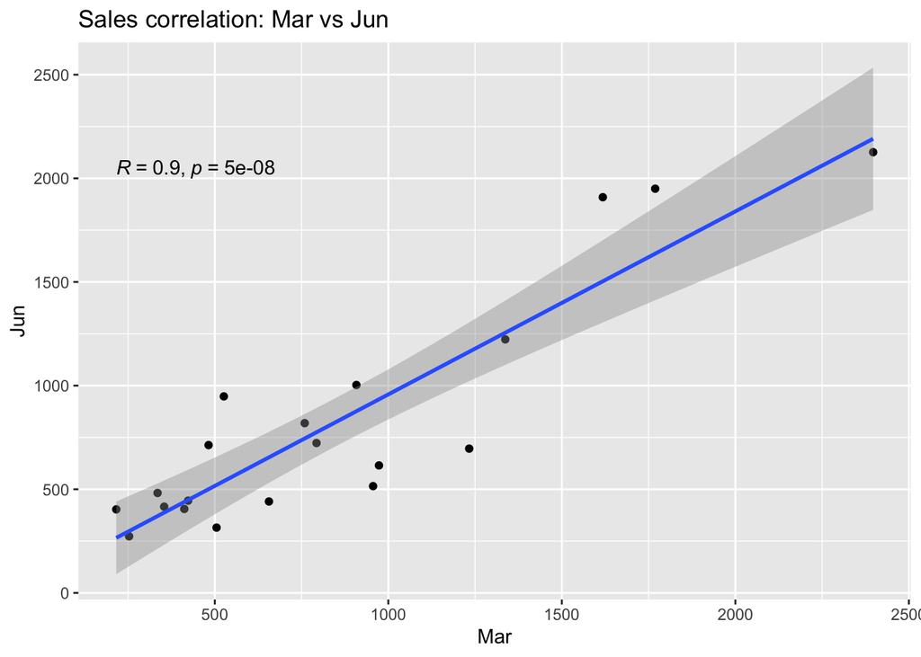

```r
ggplot(Plot_Dataframe,aes(x = First_Month_Data , y = Second_Month_Data))+
  geom_point()+
  labs(
    title = paste("Sales correlation:", Top_2_Months_names[1],"vs",
    Top_2_Months_names[2]),
    x = Top_2_Months_names[1] ,
    y = Top_2_Months_names[2]
  )+
  geom_smooth(method = "lm")+
  stat_cor()
```

```r
#according to the plot and the value of R we can say that there is a positive correlation between sales fo March and June
# ( R value is close to 1 , so the positive correlation is strong )
```

5. Convert the rownames into a column and turn the data into long format so that the data can be processed using ggplot2 (5%)

```r
Long_SalesData <- SalesData %>%
  rownames_to_column("Year") %>%
  pivot_longer(
    cols = Jan:Dec,
    names_to = "Month",
    values_to = "SalesValue"
  )
Long_SalesData
```

```
## # A tibble: 240 × 3
##    Year  Month SalesValue
##    <chr> <chr>      <int>
##  1 2003  Jan          349
##  2 2003  Feb          303
##  3 2003  Mar          216
##  4 2003  Apr          361
##  5 2003  May          331
##  6 2003  Jun          403
##  7 2003  Jul          252
##  8 2003  Aug          265
##  9 2003  Sep          289
## 10 2003  Oct          283
## # ℹ 230 more rows
```

6. Using the long form dataframe, generate a Boxplot of the sales values for the 2 years with the highest mean sales (10%)

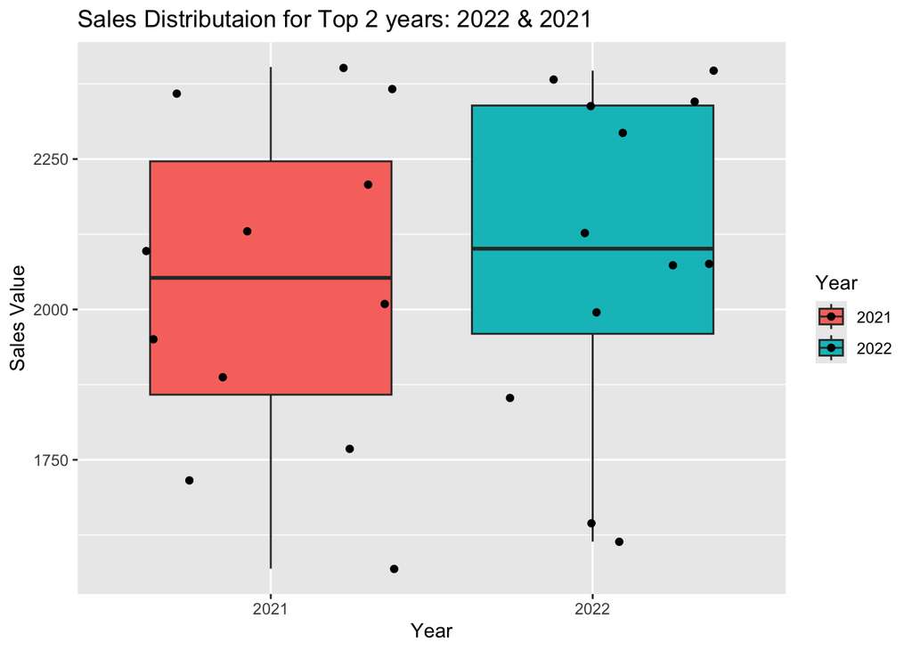

```
1.  Determine whether to use a parametric or non-parametric test for these data.
```

```r
Top_2_Years_mean_Names <- SalesData %>%
  rowMeans() %>%
  sort(decreasing = TRUE) %>%
  head(n=2) %>%
  names()

Top_2_Years_BoxPlot <- Long_SalesData %>%
  filter(Year %in% Top_2_Years_mean_Names) %>%
  ggplot(aes(x= Year, y= SalesValue, fill= Year))+
  geom_boxplot(alpha = 1)+
  geom_jitter()+
  labs(
    title = paste("Sales Distributaion for Top 2 years:",Top_2_Years_mean_Names[1],
                  "&",Top_2_Years_mean_Names[2]),
    x= "Year",
    y= "Sales Value"
  )

Top_2_Years_BoxPlot
```

```r
Top_2_Sales <- Long_SalesData %>%
  filter(Year %in% Top_2_Years_mean_Names)
#check output:
Top_2_Sales
```

```
## # A tibble: 24 × 3
##    Year  Month SalesValue
##    <chr> <chr>      <int>
##  1 2021  Jan         1888
##  2 2021  Feb         2209
##  3 2021  Mar         1769
##  4 2021  Apr         1569
##  5 2021  May         2365
##  6 2021  Jun         1950
##  7 2021  Jul         2131
##  8 2021  Aug         1716
##  9 2021  Sep         2009
## 10 2021  Oct         2403
## # ℹ 14 more rows
```

```r
Year1_Data <- Top_2_Sales %>%
  filter( Year== Top_2_Years_mean_Names[1])
shapiro.test(Year1_Data$SalesValue)
```

```
##
##  Shapiro-Wilk normality test
##
## data:  Year1_Data$SalesValue
## W = 0.89372, p-value = 0.1316
```

```r
Year2_Data <- Top_2_Sales %>%
  filter( Year== Top_2_Years_mean_Names[2])
shapiro.test(Year2_Data$SalesValue)
```

```
##
##  Shapiro-Wilk normality test
##
## data:  Year2_Data$SalesValue
## W = 0.95697, p-value = 0.7399
```

```r
# We should use parametric test(t-test) if the data is distributed normally, otherwise a non-parametric test(Wilcox-test). In This case both p-value > 0.05 , which means null hypothesis is true and our data is normal distributed , so we should use t-test.
```

```
2.  Include the correct statistics on the plot.
```

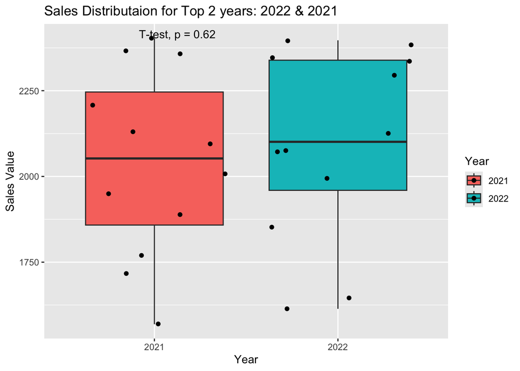

```r
Top_2_Years_BoxPlot <- Long_SalesData %>%
  filter(Year %in% Top_2_Years_mean_Names) %>%
  ggplot(aes(x= Year, y= SalesValue, fill= Year))+
  geom_boxplot(alpha = 1)+
  geom_jitter()+
  stat_compare_means(method = "t.test")+
  labs(
    title = paste("Sales Distributaion for Top 2 years:",Top_2_Years_mean_Names[1],
                  "&",Top_2_Years_mean_Names[2]),
    x= "Year",
    y= "Sales Value"
  )

Top_2_Years_BoxPlot
```

# Assessment 2 30%

1. Use the three files (Counts.tsv, SampleInfo.tsv, Genes.tsv) provided to generate an object of the expressionSet class from the Biobase package (use the first column of these files as the rownames) (5%)

```r
Expres <- read.delim("Assessment/Counts.tsv", row.names = 1)
Sample_Data <- read.delim("Assessment/SampleData.tsv", row.names = 1)
Genes_Data <- read.delim("Assessment/Genes.tsv", row.names = 1)

Expres_Matrix <- as.matrix(Expres)
PData <- AnnotatedDataFrame(Sample_Data)
FDATA <- AnnotatedDataFrame(Genes_Data)


Expression_Set <- ExpressionSet(
  assayData = Expres_Matrix,
  phenoData = PData,
  featureData = FDATA
)

Expression_Set
```

```
## ExpressionSet (storageMode: lockedEnvironment)
## assayData: 18145 features, 76 samples
##   element names: exprs
## protocolData: none
## phenoData
##   sampleNames: Sample1 Sample2 ... Sample76 (76 total)
##   varLabels: Timepoint COO Batch
##   varMetadata: labelDescription
## featureData
##   featureNames: SEC24B-AS1 A1BG ... SFMBT1 (18145 total)
##   fvarLabels: chromosome_name external_gene_name description gene_biotype
##   fvarMetadata: labelDescription
## experimentData: use 'experimentData(object)'
## Annotation:
```

2. Print out the mean expression for each sample (3%)

```r
Expression_Matrix <- exprs(Expression_Set)
Sample_Mean <- colMeans(Expression_Matrix)
print(Sample_Mean)
```

```
##   Sample1   Sample2   Sample3   Sample4   Sample5   Sample6   Sample7   Sample8   Sample9  Sample10  Sample11  Sample12  Sample13  Sample14  Sample15  Sample16  Sample17  Sample18
## 468.11810 538.88779 667.15112 495.97156 538.81967 648.65699 292.24310  68.89413 764.04806 516.06128 287.82392 124.47528 587.14919 482.84453  58.88658 491.70785 465.09540 536.91623
##  Sample19  Sample20  Sample21  Sample22  Sample23  Sample24  Sample25  Sample26  Sample27  Sample28  Sample29  Sample30  Sample31  Sample32  Sample33  Sample34  Sample35  Sample36
## 485.60298 482.38611 477.17735 403.05704 391.31375 496.36423 490.03720 485.67302 483.93888 509.16842 468.61560 269.35277 476.37906 528.13833 493.35205 510.55652 423.58363 462.00772
##  Sample37  Sample38  Sample39  Sample40  Sample41  Sample42  Sample43  Sample44  Sample45  Sample46  Sample47  Sample48  Sample49  Sample50  Sample51  Sample52  Sample53  Sample54
## 489.19162 450.97840 535.18099 418.49027 482.94136 348.97608 536.87600 541.64673 299.08570 481.47451 455.01879 407.70653 482.32229 417.71127 271.34335 500.28531 295.86779 520.41163
##  Sample55  Sample56  Sample57  Sample58  Sample59  Sample60  Sample61  Sample62  Sample63  Sample64  Sample65  Sample66  Sample67  Sample68  Sample69  Sample70  Sample71  Sample72
## 392.59399 533.63830 279.45787 423.60667 419.72141 368.82717 411.81890 347.81708 577.84282 322.71298 418.15227 629.37740 308.04459 419.59603 373.56743 387.47920 389.64844 456.50653
##  Sample73  Sample74  Sample75  Sample76
## 347.01268 478.64244  48.31843 177.64387
```

3. Find the gene with the highest median expression (5%)

```r
Median_Per_Gene <- apply(Expression_Matrix, 1, median)
Max_Median <- max(Median_Per_Gene)
Gene_Name <- names(Median_Per_Gene[Median_Per_Gene == Max_Median])


cat("Gene with the highest median expression:", Gene_Name, "\t")
```

```
## Gene with the highest median expression: RMRP
```

```r
cat("Value: ", Max_Median)
```

```
## Value:  315451.5
```

4. Find the gene with the lowest standard deviation (5%)

```r
# Gene_Name1 <- "PPME1"
# Gene_Name2 <- "RBMY1D"

# Gene_Expression_1 <- Expression_Matrix[Gene_Name1, ]
# Gene_Expression_2 <- Expression_Matrix[Gene_Name2, ]

# SD_for_GeneX1 <- sd(Gene_Expression_1)
# SD_for_GeneX2 <- sd(Gene_Expression_2)
# SD_for_GeneX1
# SD_for_GeneX2

# I found out that there are two genes with the same standard deviation (if we expand the decimal places , the two values differ by a neligible amount, so we can disregard it.)
# I used near() function two get the name of both genes as they have "nearly equal" values.


sd_expression_per_gene <- apply(Expression_Matrix, 1, sd)
Min_sd <- min(sd_expression_per_gene)
Min_sd_Gene_Name <- names(sd_expression_per_gene[near(sd_expression_per_gene,Min_sd)])



print(paste("Gene with the Lowest SD expression:", Min_sd_Gene_Name))
```

```
## [1] "Gene with the Lowest SD expression: PPME1"  "Gene with the Lowest SD expression: RBMY1D"
```

```r
cat("Value: ", Min_sd)
```

```
## Value:  0.1611363
```

5. Determine how many samples were in each batch (2%)

```r
Sample_PData <- pData(Expression_Set)
Batch_Counts <- table(Sample_PData$Batch)
print(Batch_Counts)
```

```
##
## Batch 1 Batch 2 Batch 3 Batch 4 Batch 5 Batch 6 Batch 7
##       3       8      24      21       8       6       6
```

6. Plot a boxplot of the expression of the top 10 genes ranked by standard deviation (hint: base R or ggplot2 is acceptable) (10%)

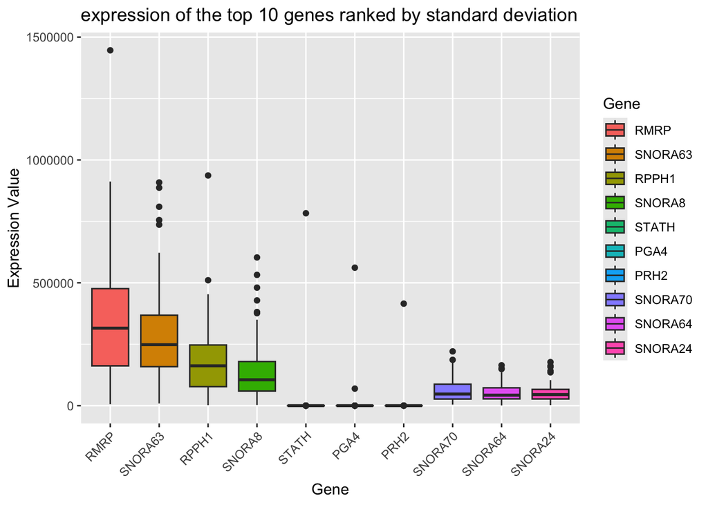

```r
Sorted_genes_sd <-names(sort(sd_expression_per_gene,decreasing = T))
Top_10_Ranked_SD <- Sorted_genes_sd[1:10]
Top_10_Ranked_SD_DF <- as.data.frame(Expression_Matrix[Top_10_Ranked_SD,])

Long_Top10 <- Top_10_Ranked_SD_DF %>%
  rownames_to_column("Gene") %>%
  pivot_longer(
    cols = matches("^Sample"),
    names_to = "Sample",
    values_to = "Expression_Value"
  )

Long_Top10$Gene <- factor(Long_Top10$Gene, levels = Top_10_Ranked_SD)

Gene_Plot  =ggplot(Long_Top10, aes(x = Gene , y=Expression_Value, fill = Gene))+
  geom_boxplot()+
  labs(
    title = "expression of the top 10 genes ranked by standard deviation",
    x = "Gene",
    y = "Expression Value"
  )+
  #The below line changes the angle and the height of the gene names to prevent them from overlapping.
  theme(axis.text.x = element_text(angle = 45 ,hjust = 1))

Gene_Plot
```

# Assessment 3 40%

Write functions that can do the following:

1. Returns a data frame containing the mean, standard deviation and median of each column in a dataframe (e.g. mtcars, or the file Sales.tsv). (10%)

```r
Calculation <- function(dataframe){
  c(
    Mean = mean(dataframe),
    SD = sd(dataframe),
    Median = median(dataframe)
  )
}

Result <- apply(mtcars, 2, Calculation)
Result
```

```
##              mpg      cyl     disp        hp      drat        wt      qsec        vs        am      gear   carb
## Mean   20.090625 6.187500 230.7219 146.68750 3.5965625 3.2172500 17.848750 0.4375000 0.4062500 3.6875000 2.8125
## SD      6.026948 1.785922 123.9387  68.56287 0.5346787 0.9784574  1.786943 0.5040161 0.4989909 0.7378041 1.6152
## Median 19.200000 6.000000 196.3000 123.00000 3.6950000 3.3250000 17.710000 0.0000000 0.0000000 4.0000000 2.0000
```

For questions (2) and (3) below, use the following DNA sequence exampleDNASequence <-c(“TTGGTCATCCTAGACACGCGCCCTACCTGTCAAAATCTAAAATTCATCATACCCTGCGGACGGTGCTTCTGTGCCGAGGCGCAGGCCGATATGTTTCTAC”)

2. Take a string containing a DNA sequence, convert this to a vector, which each entry being one base. (Hint: strsplit in conjuction with unlist). (15%)

```r
exampleDNASequence <-c("TTGGTCATCCTAGACACGCGCCCTACCTGTCAAAATCTAAAATTCATCATACCCTGCGGACGGTGCTTCTGTGCCGAGGCGCAGGCCGATATGTTTCTAC")

OneBase_vector <- function(DNA_String){
  nucleotides = unlist(strsplit(DNA_String,""))
  return(nucleotides)
}

OneBase_vector(exampleDNASequence)
```

```
##   [1] "T" "T" "G" "G" "T" "C" "A" "T" "C" "C" "T" "A" "G" "A" "C" "A" "C" "G" "C" "G" "C" "C" "C" "T" "A" "C" "C" "T" "G" "T" "C" "A" "A" "A" "A" "T" "C" "T" "A" "A" "A" "A" "T" "T" "C"
##  [46] "A" "T" "C" "A" "T" "A" "C" "C" "C" "T" "G" "C" "G" "G" "A" "C" "G" "G" "T" "G" "C" "T" "T" "C" "T" "G" "T" "G" "C" "C" "G" "A" "G" "G" "C" "G" "C" "A" "G" "G" "C" "C" "G" "A" "T"
##  [91] "A" "T" "G" "T" "T" "T" "C" "T" "A" "C"
```

```
1. Calculate the length of the sequences, the amount of each of the four nucleotides, A, T, G and C. Return these as a vector with each item named (i.e. length, A, T, G, C)
```

```r
exampleDNASequence <-c("TTGGTCATCCTAGACACGCGCCCTACCTGTCAAAATCTAAAATTCATCATACCCTGCGGACGGTGCTTCTGTGCCGAGGCGCAGGCCGATATGTTTCTAC")



Sequence_Info <- function(DNA_String){
  nucleotides = unlist(strsplit(DNA_String,""))

  Sequence_Length <- length(nucleotides)
  countA <- sum(nucleotides == "A")
  countT <- sum(nucleotides == "T")
  countG <- sum(nucleotides == "G")
  countC <- sum(nucleotides == "C")

  return(c(
    Length = Sequence_Length,
    A = countA,
    T = countT,
    G = countG,
    C = countC
  ))
}

Sequence_Info(exampleDNASequence)
```

```
## Length      A      T      G      C
##    100     22     26     22     30
```

3. Write a function that takes a DNA sequence and substitutes one nucleotide specified by an argument (default value “A”) for another nucleotide specified by an argument (default value “T”). This function should return a named list with both the original and the new string of nucleotides. (15%)

```r
exampleDNASequence <-c("TTGGTCATCCTAGACACGCGCCCTACCTGTCAAAATCTAAAATTCATCATACCCTGCGGACGGTGCTTCTGTGCCGAGGCGCAGGCCGATATGTTTCTAC")

Substitution <-function(Sequence, old_nucleotide="A",new_nucleotide="T"){
  Original_string <- Sequence
  New_string <- gsub(old_nucleotide, new_nucleotide,Sequence)
  OLD_NEW_SEQUENCE <- list( OLD = Original_string , NEW = New_string)
  return(OLD_NEW_SEQUENCE)
}
Substitution(exampleDNASequence)
```

```
## $OLD
## [1] "TTGGTCATCCTAGACACGCGCCCTACCTGTCAAAATCTAAAATTCATCATACCCTGCGGACGGTGCTTCTGTGCCGAGGCGCAGGCCGATATGTTTCTAC"
##
## $NEW
## [1] "TTGGTCTTCCTTGTCTCGCGCCCTTCCTGTCTTTTTCTTTTTTTCTTCTTTCCCTGCGGTCGGTGCTTCTGTGCCGTGGCGCTGGCCGTTTTGTTTCTTC"
```